# SERL response/consent model testing

Exploring D-W stat issues and testing results plotting methods

Ben Anderson

Last run at: 2020-10-29 15:24:31

# Setup

Load the packages etc we need.

```r
knitr::opts_chunk$set(echo = TRUE)

library(data.table) # big fast data
library(skimr) # summary on steroids
library(ggplot2) # pretty plots
library(kableExtra) # pretty tables
library(broom) # tidy up regression outputs
library(car) # model diagnostics
library(here) # so useful - relative repo paths!
library(stargazer) # pretty model tables
user <- Sys.info()[[7]]
if(user == "ben"){
  dataF <- path.expand("~/temp/serlRecruit18000.csv")
} # else...
```

# Introduction

Testing non-response models for the SERL pilot data…

# Data

18,000 cases - the households to whom letters were sent

```r
all_onboards <- data.table::fread(dataF)

skimr::skim(all_onboards)
```

Data summary

| Name | all_onboards |
| --- | --- |
| Number of rows | 18000 |
| Number of columns | 8 |
| _______________________ |  |
| Column type frequency: |  |
| character | 3 |
| logical | 2 |
| numeric | 3 |
| ________________________ |  |
| Group variables | None |

**Variable type: character**

| skim_variable | n_missing | complete_rate | min | max | empty | n_unique | whitespace |
| --- | --- | --- | --- | --- | --- | --- | --- |
| region | 0 | 1 | 5 | 15 | 0 | 7 | 0 |
| consent_source | 0 | 1 | 4 | 6 | 0 | 3 | 0 |
| incentive | 0 | 1 | 4 | 11 | 0 | 3 | 0 |

**Variable type: logical**

| skim_variable | n_missing | complete_rate | mean | count |
| --- | --- | --- | --- | --- |
| p2w | 0 | 1 | 0.5 | FAL: 9000, TRU: 9000 |
| consent | 0 | 1 | 0.1 | FAL: 16289, TRU: 1711 |

**Variable type: numeric**

| skim_variable | n_missing | complete_rate | mean | sd | p0 | p25 | p50 | p75 | p100 | hist |
| --- | --- | --- | --- | --- | --- | --- | --- | --- | --- | --- |
| quintile | 0 | 1 | 3.06 | 1.37 | 1 | 2.00 | 3.0 | 4.00 | 5 | ▆▇▇▇▇ |
| cell | 0 | 1 | 6.50 | 3.45 | 1 | 3.75 | 6.5 | 9.25 | 12 | ▇▅▅▅▇ |
| version | 0 | 1 | 1.50 | 0.50 | 1 | 1.00 | 1.5 | 2.00 | 2 | ▇▁▁▁▇ |

# Descriptive stats

We care about:

- `consent` - if they gave consent for smart meter data to be collected
- `region` - govt office region of address (England & Wales)
- `consent_source` - postal or online
- `incentive` - the incentive they received (if any)
- `p2w` - whether they were push to web or not
- `quintile` - IMD quintile of the LSOA the address is in, 1 = most deprived (XX check coding XX)
- `cell` - the combination of recruitment processes received
- `version` - ?

First we’ll look at consent rates by region. We wouldn’t really expect a regional consent effect…

```r
tr <- table(all_onboards$region, all_onboards$consent)
kableExtra::kable(addmargins(tr), caption = "Number of consents by region", digits = 2) %>%
  kable_styling()
```

Number of consents by region

|  | FALSE | TRUE | Sum |
| --- | --- | --- | --- |
| EAST MIDLANDS | 1812 | 158 | 1970 |
| EAST OF ENGLAND | 2244 | 262 | 2506 |
| GREATER LONDON | 3283 | 297 | 3580 |
| SOUTH EAST | 3305 | 369 | 3674 |
| SOUTH WEST | 2187 | 256 | 2443 |
| WALES | 1300 | 171 | 1471 |
| WEST MIDLANDS | 2158 | 198 | 2356 |
| Sum | 16289 | 1711 | 18000 |

```r
trp <- prop.table(tr, 1)*100
kableExtra::kable(trp, caption = "% consents by region", digits = 2) %>%
  kable_styling()
```

% consents by region

|  | FALSE | TRUE |
| --- | --- | --- |
| EAST MIDLANDS | 91.98 | 8.02 |
| EAST OF ENGLAND | 89.55 | 10.45 |
| GREATER LONDON | 91.70 | 8.30 |
| SOUTH EAST | 89.96 | 10.04 |
| SOUTH WEST | 89.52 | 10.48 |
| WALES | 88.38 | 11.62 |
| WEST MIDLANDS | 91.60 | 8.40 |

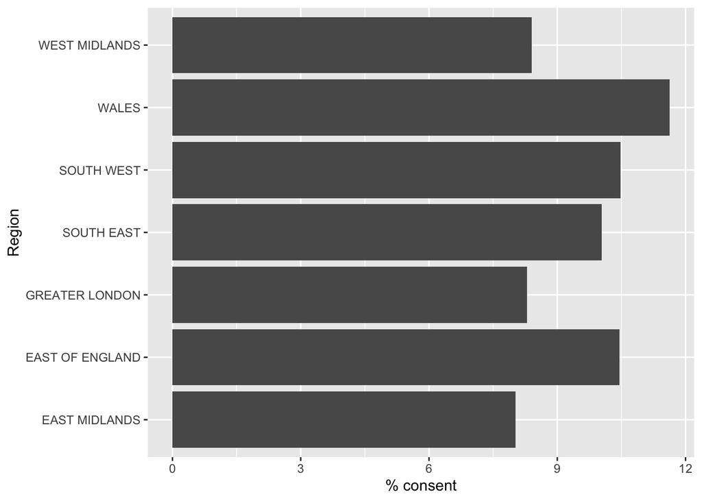

% consent by region

```r
plotDT <- as.data.table(trp)
ggplot2::ggplot(plotDT[V2 == "TRUE"], aes(y = V1, x = N)) +
  geom_col() +
  labs(x = "% consent",
       y = "Region")
```

```r
# how do we order x axis by size of y value?
```

There are some slight differences between regions but nothing too notable. It may be the case that regional effects are confounded by IMD (etc) effects.

Repeat this for IMD - plots need CI

```r
tr <- table(all_onboards$quintile, all_onboards$consent)
kableExtra::kable(addmargins(tr), caption = "Consents by IMD quintile", digits = 2) %>%
  kable_styling()
```

Consents by IMD quintile

|  | FALSE | TRUE | Sum |
| --- | --- | --- | --- |
| 1 | 2790 | 191 | 2981 |
| 2 | 3549 | 289 | 3838 |
| 3 | 3570 | 347 | 3917 |
| 4 | 3302 | 432 | 3734 |
| 5 | 3078 | 452 | 3530 |
| Sum | 16289 | 1711 | 18000 |

```r
trp <- prop.table(tr, 1)*100
kableExtra::kable(trp, caption = "% consents by IMD quintile", digits = 2) %>%
  kable_styling()
```

% consents by IMD quintile

| FALSE | TRUE |
| --- | --- |
| 93.59 | 6.41 |
| 92.47 | 7.53 |
| 91.14 | 8.86 |
| 88.43 | 11.57 |
| 87.20 | 12.80 |

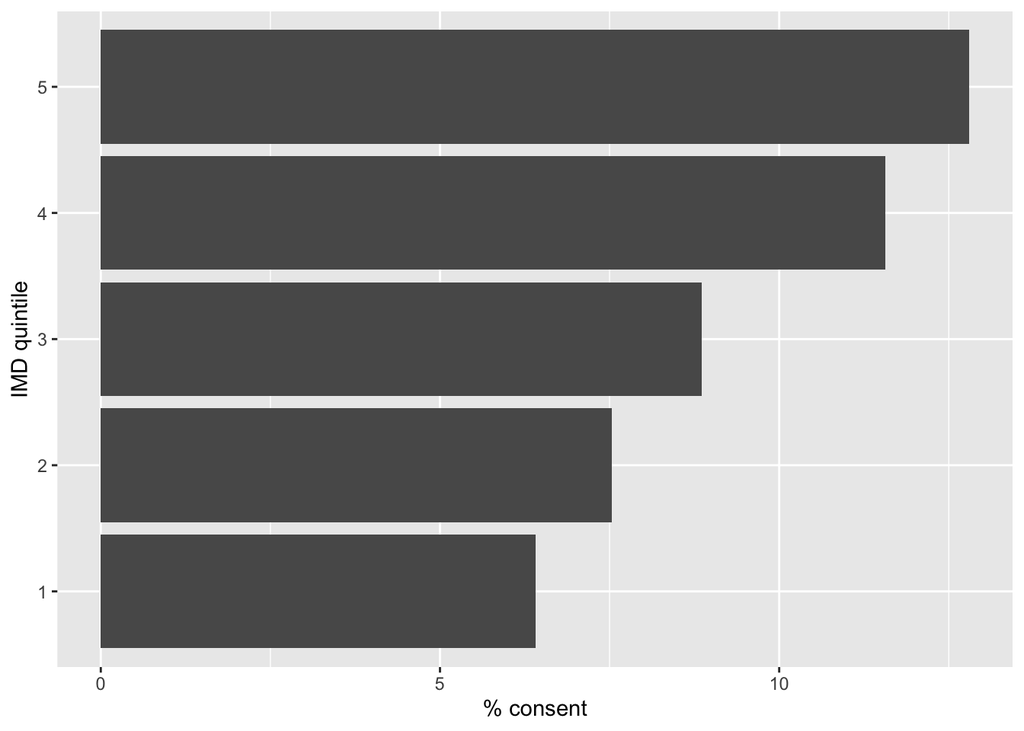

% consent by IMD quintile

```r
plotDT <- as.data.table(trp)
ggplot2::ggplot(plotDT[V2 == "TRUE"], aes(y = V1, x = N)) +
  geom_col() +
  labs(x = "% consent",
       y = "IMD quintile")
```

In this case we do see more of a relationship - consent rates also increase as IMD quintile increases (less deprived).

Do we have relatively evenly distributed cases by IMD and region? If we don’t then a correlation between IMD and consent rates may lead to an apparent (spurious) regional non-consent rate.

```r
t <- table(all_onboards$region, all_onboards$quintile)
t # table of case frequency by IMD & region
```

```
##
##                      1    2    3    4    5
##   EAST MIDLANDS    376  406  372  430  386
##   EAST OF ENGLAND  266  469  617  576  578
##   GREATER LONDON   824 1134  759  548  315
##   SOUTH EAST       282  573  736  880 1203
##   SOUTH WEST       281  506  640  571  445
##   WALES            279  297  317  316  262
##   WEST MIDLANDS    673  453  476  413  341
```

```r
round(prop.table(t,1)*100,2)
```

```
##
##                       1     2     3     4     5
##   EAST MIDLANDS   19.09 20.61 18.88 21.83 19.59
##   EAST OF ENGLAND 10.61 18.72 24.62 22.98 23.06
##   GREATER LONDON  23.02 31.68 21.20 15.31  8.80
##   SOUTH EAST       7.68 15.60 20.03 23.95 32.74
##   SOUTH WEST      11.50 20.71 26.20 23.37 18.22
##   WALES           18.97 20.19 21.55 21.48 17.81
##   WEST MIDLANDS   28.57 19.23 20.20 17.53 14.47
```

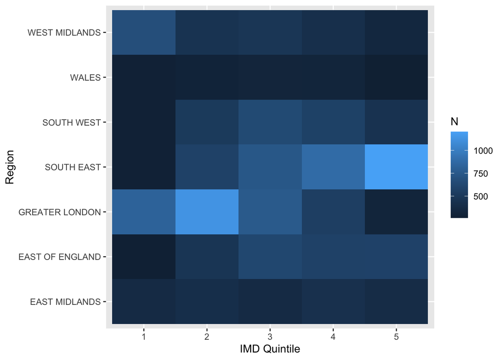

Counts of addresses contacted by region and IMD quintile

```r
# interesting dominance of IMD Q5 in South East

dt <- as.data.table(t)

ggplot2::ggplot(dt, aes(y = V1, x = V2, fill = N)) +
  geom_tile() +
  labs(y = "Region",
       x = "IMD Quintile")
```

Figure @ref(fig:crossTabPlot) (and the preceeding table) show that we have some IMD quintiles in some regions that have more cases than we might expect. This is likely to reflect:

- a preponderance of those IMD quintiles in that region and/or
- an over-sampling of those IMD quintiles due to them being more likely to have smart meters already installed.

The latter seems unlikely…

We can repeat this analysis using `gmodels::CrossTable` which gives both counts and proportions.

```r
# table of row % with last row as frequency by IMD quin
# requires gmodels
gmodels::CrossTable(all_onboards$region, all_onboards$quintile,
           prop.chisq = FALSE,
           prop.r = TRUE, # row proportions
           prop.t = FALSE, # no table props
           prop.c = FALSE, # col proportions
           chisq = TRUE,
           dnn = c("Outcome","IMD quintile") )#how do we turn off observed frequencies?
```

```
##
##
##    Cell Contents
## |-------------------------|
## |                       N |
## |           N / Row Total |
## |-------------------------|
##
##
## Total Observations in Table:  18000
##
##
##                 | IMD quintile
##         Outcome |         1 |         2 |         3 |         4 |         5 | Row Total |
## ----------------|-----------|-----------|-----------|-----------|-----------|-----------|
##   EAST MIDLANDS |       376 |       406 |       372 |       430 |       386 |      1970 |
##                 |     0.191 |     0.206 |     0.189 |     0.218 |     0.196 |     0.109 |
## ----------------|-----------|-----------|-----------|-----------|-----------|-----------|
## EAST OF ENGLAND |       266 |       469 |       617 |       576 |       578 |      2506 |
##                 |     0.106 |     0.187 |     0.246 |     0.230 |     0.231 |     0.139 |
## ----------------|-----------|-----------|-----------|-----------|-----------|-----------|
##  GREATER LONDON |       824 |      1134 |       759 |       548 |       315 |      3580 |
##                 |     0.230 |     0.317 |     0.212 |     0.153 |     0.088 |     0.199 |
## ----------------|-----------|-----------|-----------|-----------|-----------|-----------|
##      SOUTH EAST |       282 |       573 |       736 |       880 |      1203 |      3674 |
##                 |     0.077 |     0.156 |     0.200 |     0.240 |     0.327 |     0.204 |
## ----------------|-----------|-----------|-----------|-----------|-----------|-----------|
##      SOUTH WEST |       281 |       506 |       640 |       571 |       445 |      2443 |
##                 |     0.115 |     0.207 |     0.262 |     0.234 |     0.182 |     0.136 |
## ----------------|-----------|-----------|-----------|-----------|-----------|-----------|
##           WALES |       279 |       297 |       317 |       316 |       262 |      1471 |
##                 |     0.190 |     0.202 |     0.215 |     0.215 |     0.178 |     0.082 |
## ----------------|-----------|-----------|-----------|-----------|-----------|-----------|
##   WEST MIDLANDS |       673 |       453 |       476 |       413 |       341 |      2356 |
##                 |     0.286 |     0.192 |     0.202 |     0.175 |     0.145 |     0.131 |
## ----------------|-----------|-----------|-----------|-----------|-----------|-----------|
##    Column Total |      2981 |      3838 |      3917 |      3734 |      3530 |     18000 |
## ----------------|-----------|-----------|-----------|-----------|-----------|-----------|
##
##
## Statistics for All Table Factors
##
##
## Pearson's Chi-squared test
## ------------------------------------------------------------
## Chi^2 =  1557.547     d.f. =  24     p =  9.851143e-315
##
##
##
```

So both Figure @ref(fig:crossTabPlot) and the CrossTab results are telling us that:

- IMD 5 appears over-represented in South East (but perhaps most SE LSOAs are in IMD 5?)
- IMD 2 appears over-represented in London
- IMD 1 appears over-represented in West Midlands

> But: we need to check if these row % distributions match the IMD * Region distribution of LSOAs? If they do then there is no problem. If not then have we got over/under sampling going on by IMD?

# Simple non-response model

## Orignal data as loaded

Next we’ll build a simple non-response model and test it.

- outcome/dependent variable : consent
- independent variables: region + quintile

```r
table(all_onboards$consent, useNA = "always") # check for NA
```

```
##
## FALSE  TRUE  <NA>
## 16289  1711     0
```

```r
prop.table(table(all_onboards$consent, useNA = "always")) # check for NA
```

```
##
##      FALSE       TRUE       <NA>
## 0.90494444 0.09505556 0.00000000
```

```r
m <- glm(formula = consent ~ as.factor(quintile) +
                          region,
                       family = binomial(logit), all_onboards) # wiil auto-drop the missing values

summary(m)
```

```
##
## Call:
## glm(formula = consent ~ as.factor(quintile) + region, family = binomial(logit),
##     data = all_onboards)
##
## Deviance Residuals:
##     Min       1Q   Median       3Q      Max
## -0.5845  -0.4861  -0.4201  -0.3830   2.4121
##
## Coefficients:
##                       Estimate Std. Error z value Pr(>|z|)
## (Intercept)           -2.85308    0.10879 -26.226  < 2e-16 ***
## as.factor(quintile)2   0.16414    0.09711   1.690 0.090995 .
## as.factor(quintile)3   0.33034    0.09449   3.496 0.000472 ***
## as.factor(quintile)4   0.63049    0.09194   6.857 7.02e-12 ***
## as.factor(quintile)5   0.75028    0.09265   8.098 5.60e-16 ***
## regionEAST OF ENGLAND  0.24877    0.10603   2.346 0.018960 *
## regionGREATER LONDON   0.13956    0.10363   1.347 0.178050
## regionSOUTH EAST       0.14624    0.10026   1.459 0.144661
## regionSOUTH WEST       0.27751    0.10650   2.606 0.009168 **
## regionWALES            0.42244    0.11659   3.623 0.000291 ***
## regionWEST MIDLANDS    0.11427    0.11190   1.021 0.307160
## ---
## Signif. codes:  0 '***' 0.001 '**' 0.01 '*' 0.05 '.' 0.1 ' ' 1
##
## (Dispersion parameter for binomial family taken to be 1)
##
##     Null deviance: 11307  on 17999  degrees of freedom
## Residual deviance: 11173  on 17989  degrees of freedom
## AIC: 11195
##
## Number of Fisher Scoring iterations: 5
```

As we might expect from the descriptive tables, the results suggest region is a relatively weak predictor of consent but consent rates increase in higher (least deprived) IMD areas.

Run diagnostics to check the model…

```r
# Independence of errors
car::durbinWatsonTest(m)
```

```
##  lag Autocorrelation D-W Statistic p-value
##    1       0.9973258   0.004971946       0
##  Alternative hypothesis: rho != 0
```

```r
# if p < 0.05 then a problem as implies autocorrelation
```

DW is very close to 0 which implies strong autocorrelation of the errors. This is odd. Let’s check the residuals to see what is going on.

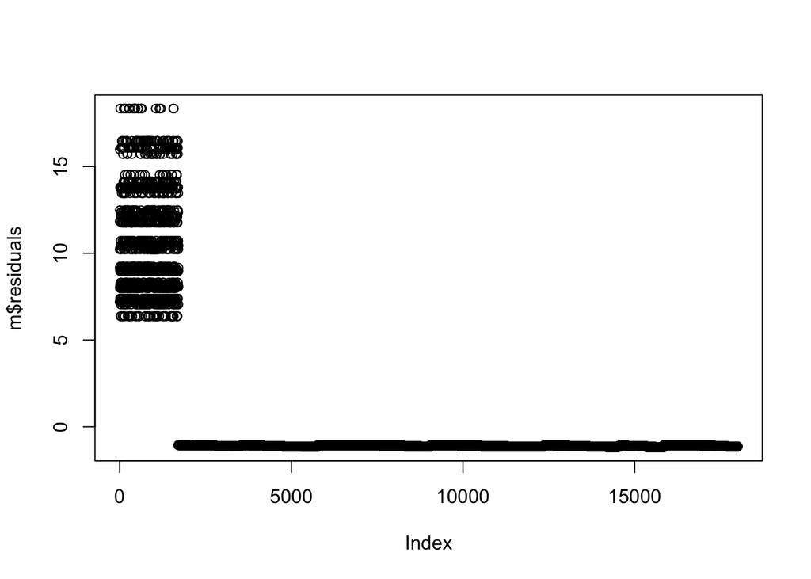

```r
plot(m$residuals)
```

So that looks like the first n rows are ‘TRUE’ and the last n rows are ‘FALSE’. This will cause the DW stat to go AWOL…

We’ll run the other diagnostics just to check. First collinearity.

```r
# requires library(car)
# Collinearity (vif)
car::vif(m)
```

```
##                         GVIF Df GVIF^(1/(2*Df))
## as.factor(quintile) 1.086677  4        1.010445
## region              1.086677  6        1.006951
```

```r
# if any values > 10 -> problem

# Collinearity (tolerance)
1/car::vif(m)
```

```
##                          GVIF        Df GVIF^(1/(2*Df))
## as.factor(quintile) 0.9202364 0.2500000       0.9896632
## region              0.9202364 0.1666667       0.9930969
```

```r
# if any values < 0.2 -> possible problem
# if any values < 0.1 -> definitely a problem=
```

Looks OK.

Now model diagnostic plots.

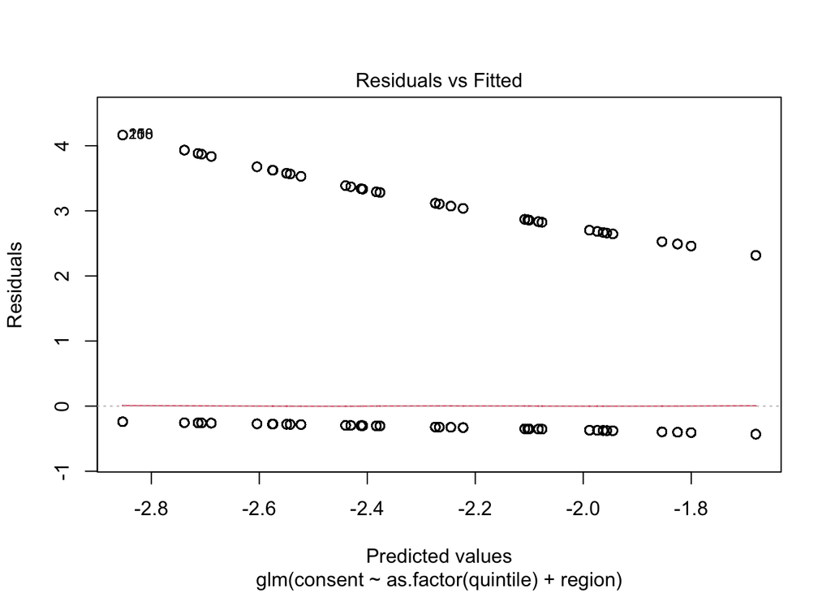

Diagnostic plots: original

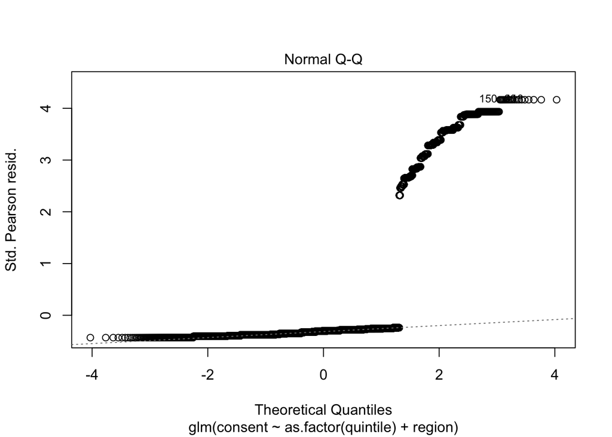

Diagnostic plots: original

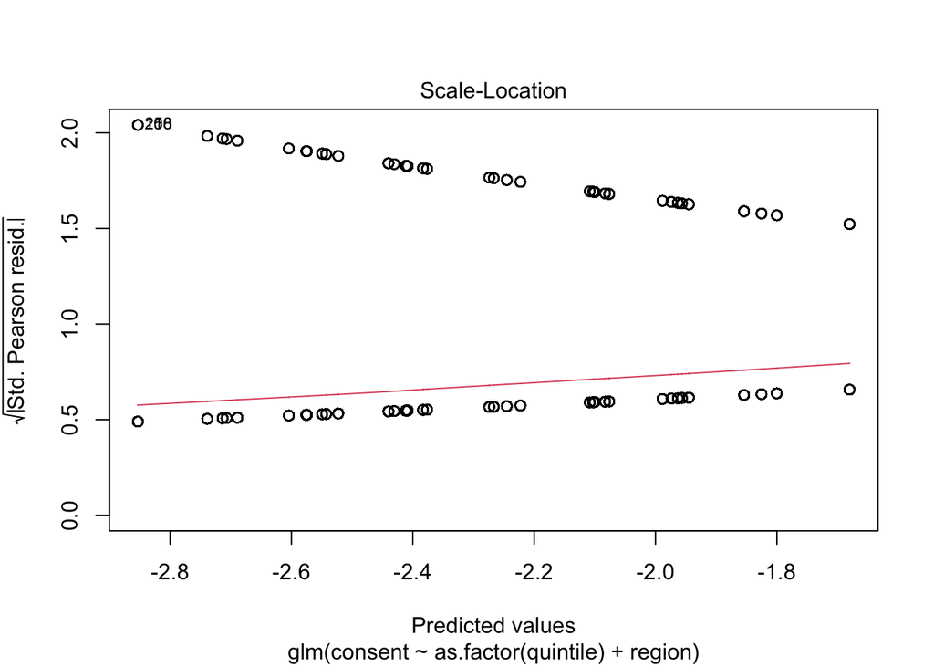

Diagnostic plots: original

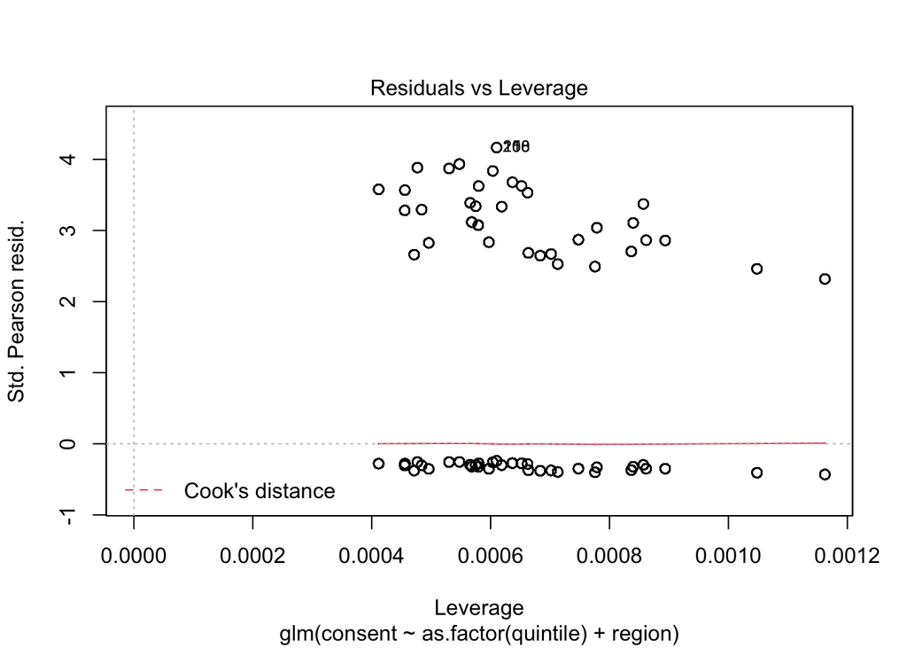

Diagnostic plots: original

```r
# Diagnostic plots ----
plot(m)
```

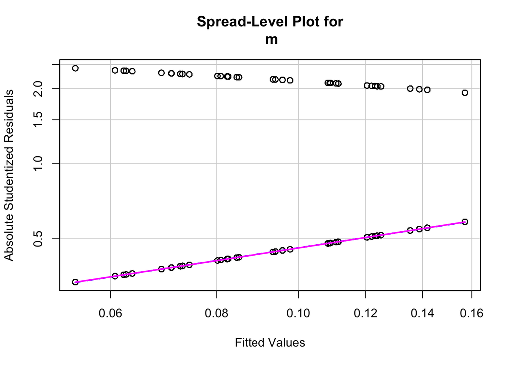

Diagnostic plots: original

```
##
## Suggested power transformation:  0.4744183
```

```r
car::spreadLevelPlot(m)
```

```r
# Suggested power transformation:  0.4744183
```

Also looks OK.

```r
# CIs for coef not OR for plot
coefCI <- cbind(coef = coef(m),
                confint(m))
df <- broom::tidy(m)
df$model <- "1. Original"

originalModelDT <- data.table::as.data.table(cbind(coefCI, df)) # collect for later plot

mOrig <- m
```

## Randomly shuffled data

If we are correct then we need to randomly shuffle the data unless we care about it’s order - for example if we though there might be a relationship between consent rates and dates.

```r
# OK, so let's shuffle the original data randomly
all_onboards <- all_onboards[sample(nrow(all_onboards)),]

m <- glm(formula = consent ~ as.factor(quintile) +
                          region,
                       family = binomial(logit), all_onboards) # wiil auto-drop the missing values

summary(m)
```

```
##
## Call:
## glm(formula = consent ~ as.factor(quintile) + region, family = binomial(logit),
##     data = all_onboards)
##
## Deviance Residuals:
##     Min       1Q   Median       3Q      Max
## -0.5845  -0.4861  -0.4201  -0.3830   2.4121
##
## Coefficients:
##                       Estimate Std. Error z value Pr(>|z|)
## (Intercept)           -2.85308    0.10879 -26.226  < 2e-16 ***
## as.factor(quintile)2   0.16414    0.09711   1.690 0.090995 .
## as.factor(quintile)3   0.33034    0.09449   3.496 0.000472 ***
## as.factor(quintile)4   0.63049    0.09194   6.857 7.02e-12 ***
## as.factor(quintile)5   0.75028    0.09265   8.098 5.60e-16 ***
## regionEAST OF ENGLAND  0.24877    0.10603   2.346 0.018960 *
## regionGREATER LONDON   0.13956    0.10363   1.347 0.178050
## regionSOUTH EAST       0.14624    0.10026   1.459 0.144661
## regionSOUTH WEST       0.27751    0.10650   2.606 0.009168 **
## regionWALES            0.42244    0.11659   3.623 0.000291 ***
## regionWEST MIDLANDS    0.11427    0.11190   1.021 0.307160
## ---
## Signif. codes:  0 '***' 0.001 '**' 0.01 '*' 0.05 '.' 0.1 ' ' 1
##
## (Dispersion parameter for binomial family taken to be 1)
##
##     Null deviance: 11307  on 17999  degrees of freedom
## Residual deviance: 11173  on 17989  degrees of freedom
## AIC: 11195
##
## Number of Fisher Scoring iterations: 5
```

The model results should be identical - we’ll double check this by plotting them sude by side later.

Now, check the D-W…

```r
# Independence of errors
car::durbinWatsonTest(m)
```

```
##  lag Autocorrelation D-W Statistic p-value
##    1      0.05855174      1.882852       0
##  Alternative hypothesis: rho != 0
```

```r
# if p < 0.05 then a problem as implies autocorrelation
```

Good, that’s more what we expected. D-W is close to 2 which indicates no auto-correlation of errors. The p value is driven by the n and is of less diagnostic value.

Check the residuals plot.

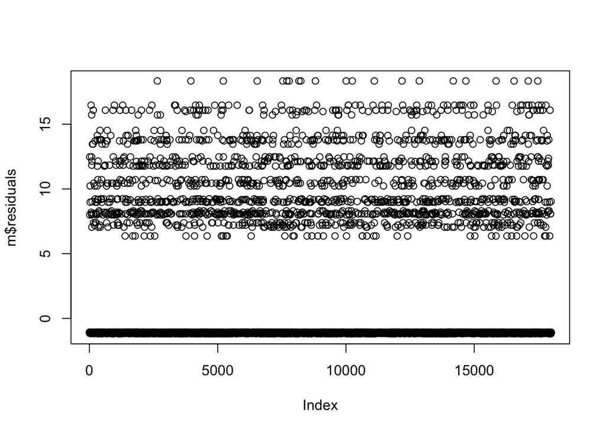

```r
plot(m$residuals)
```

Yep, random noise

We’ll run the other diagnostics just to check. First collinearity.

```r
# requires library(car)
# Collinearity (vif)
car::vif(m)
```

```
##                         GVIF Df GVIF^(1/(2*Df))
## as.factor(quintile) 1.086677  4        1.010445
## region              1.086677  6        1.006951
```

```r
# if any values > 10 -> problem

# Collinearity (tolerance)
1/car::vif(m)
```

```
##                          GVIF        Df GVIF^(1/(2*Df))
## as.factor(quintile) 0.9202364 0.2500000       0.9896632
## region              0.9202364 0.1666667       0.9930969
```

```r
# if any values < 0.2 -> possible problem
# if any values < 0.1 -> definitely a problem=
```

Looks OK.

Now model diagnostic plots.

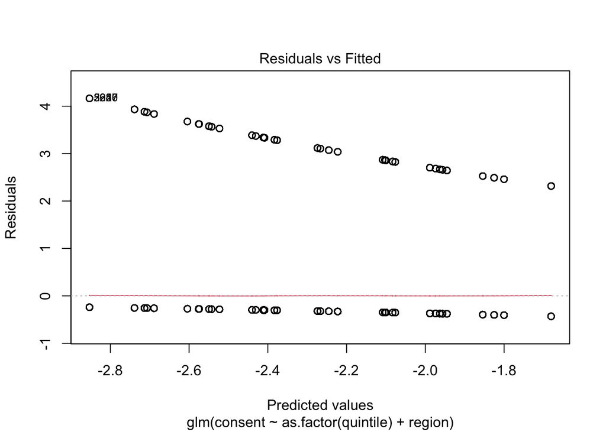

Diagnostic plots: original

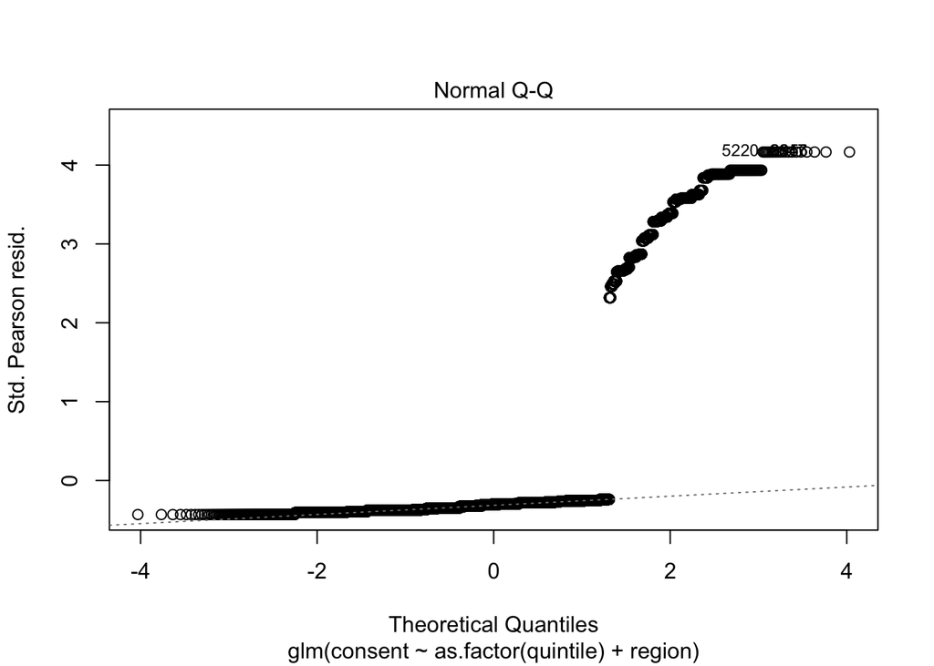

Diagnostic plots: original

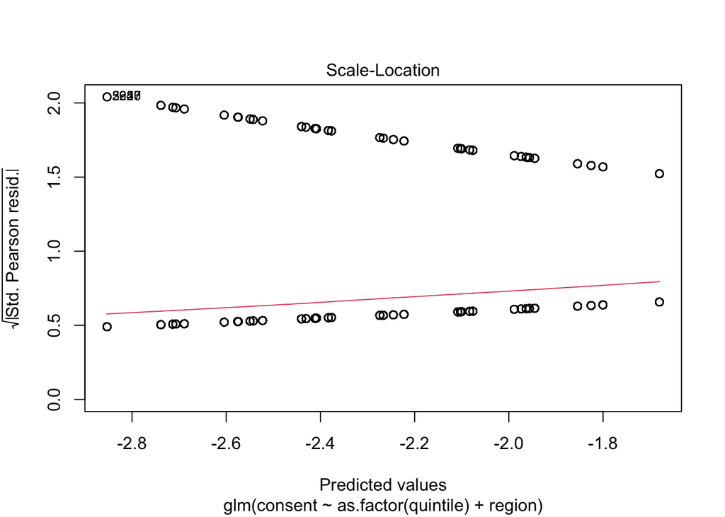

Diagnostic plots: original

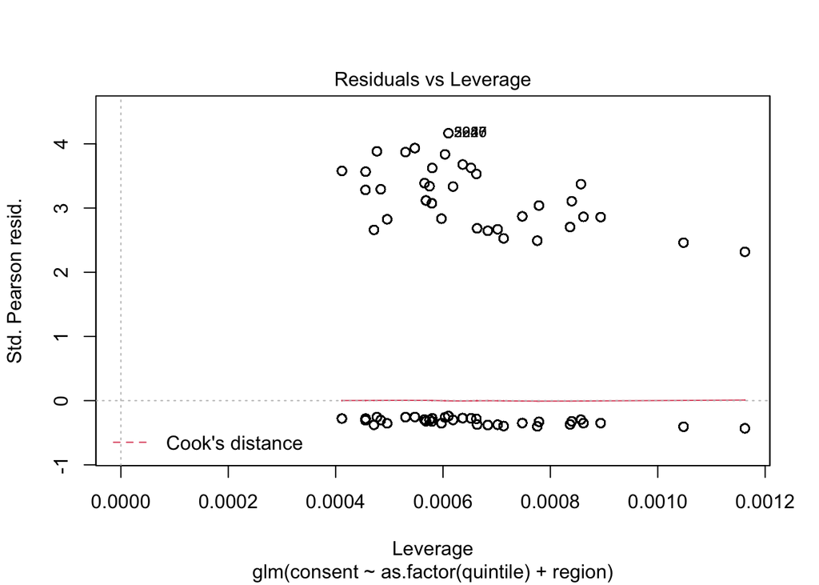

Diagnostic plots: original

```r
# Diagnostic plots ----
plot(m)
```

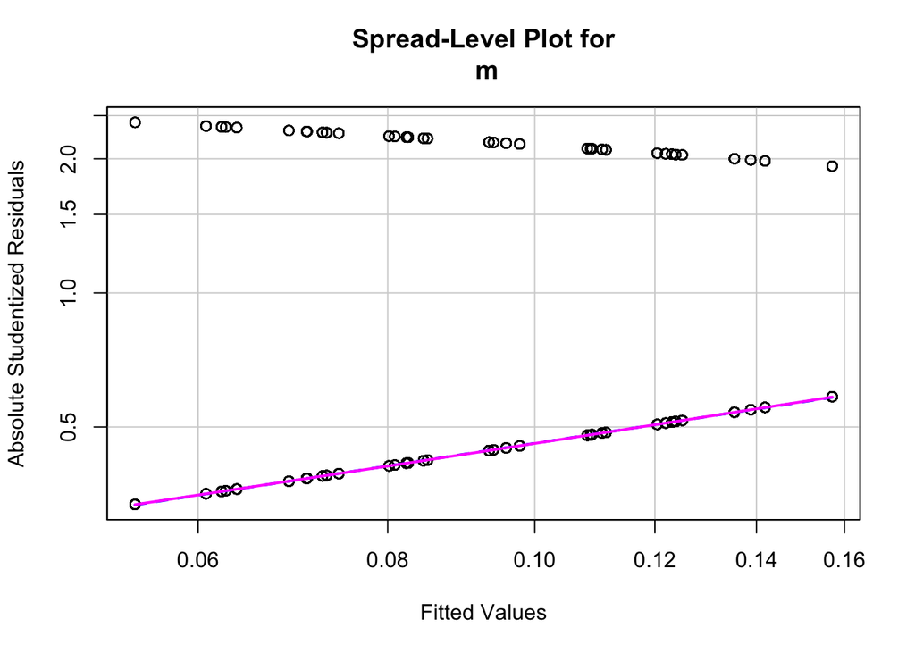

Diagnostic plots: original

```
##
## Suggested power transformation:  0.4744183
```

```r
car::spreadLevelPlot(m)
```

```r
# Suggested power transformation:  0.4744183
```

Also looks OK.

```r
# CIs for coef not OR for plot
coefCI <- cbind(coef = coef(m),
                confint(m))
df <- broom::tidy(m)
df$model <- "2. Shuffled"

shuffledModelDT <- data.table::as.data.table(cbind(coefCI, df)) # collect for later plot
mShuffled <- m
```

## Compare the models

We can plot the two model coefficients and CIs side by side to check they are the same. This is also a useful way to visualise the model results.

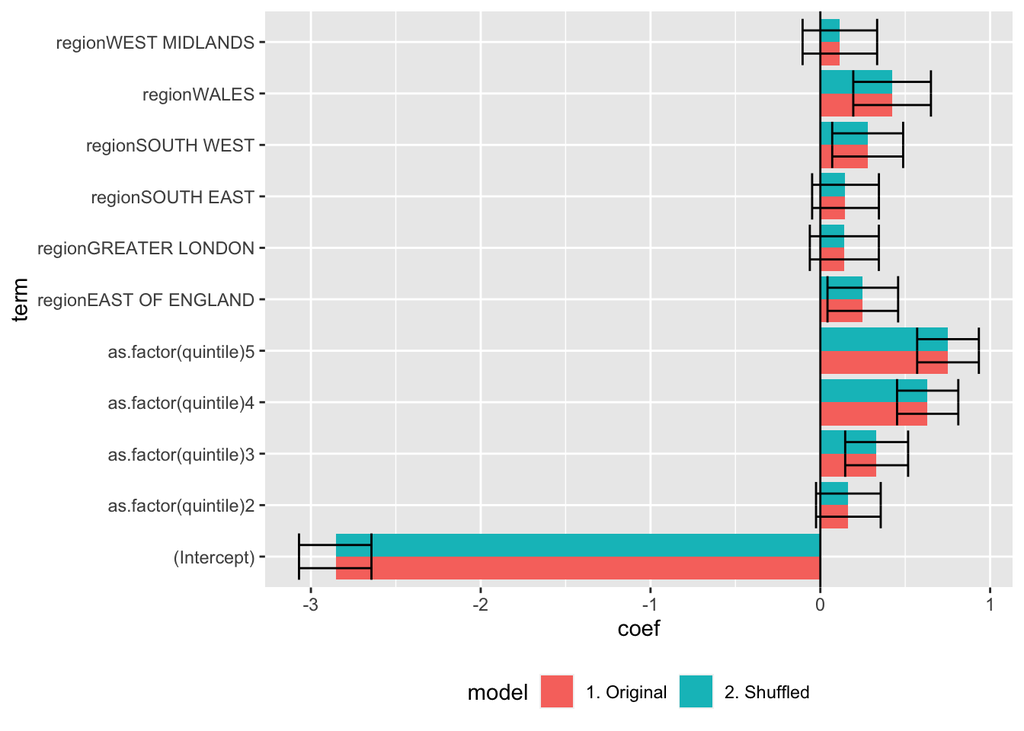

Comparing simple consent models

```r
plotDT <- rbind(originalModelDT, shuffledModelDT)
data.table::setnames(plotDT, c("2.5 %","97.5 %"), c("lo", "up")) # for easier ggplotting

p <- ggplot2::ggplot(plotDT, aes(x = coef, y = term , fill = model)) +
  geom_col(position = "dodge") +
  geom_errorbar(aes(xmax = up, xmin = lo),position = "dodge") +
  geom_vline(xintercept = 0) +
  theme(legend.position="bottom")
p
```

```r
ggplot2::ggsave("compareOriginalShuffled.png", plot = p,
                path = here::here("plots"))
```

As we can see the model results are identical. We can also see that the intercept is doing a lot of work for us, we have a couple of region effects and we can be more confident about the IMD effects as we have controlled for region…

At this stage we’ll generate a pretty model output table for the shuffled model (although it doesn’t matter which we choose). For this we use the `stargazer` package. And it saves this table for us too.

```r
stargazer::stargazer(mShuffled,
                     type = "html",
                     title="Shuffled Model", digits=3,
                     out=here::here("outputTables","shuffledModel.txt"))
```

**Shuffled Model**

|  | *Dependent variable:* |
| --- | --- |
|  | consent |
| as.factor(quintile)2 | 0.164* |
|  | (0.097) |
| as.factor(quintile)3 | 0.330*** |
|  | (0.094) |
| as.factor(quintile)4 | 0.630*** |
|  | (0.092) |
| as.factor(quintile)5 | 0.750*** |
|  | (0.093) |
| regionEAST OF ENGLAND | 0.249** |
|  | (0.106) |
| regionGREATER LONDON | 0.140 |
|  | (0.104) |
| regionSOUTH EAST | 0.146 |
|  | (0.100) |
| regionSOUTH WEST | 0.278*** |
|  | (0.106) |
| regionWALES | 0.422*** |
|  | (0.117) |
| regionWEST MIDLANDS | 0.114 |
|  | (0.112) |
| Constant | -2.853*** |
|  | (0.109) |
| Observations | 18,000 |
| Log Likelihood | -5,586.562 |
| Akaike Inf. Crit. | 11,195.120 |
| *Note:* | p<0.1; p<0.05; p<0.01 |

# Complex non-response model: adding model co-variates

Having established our base model we’ll now add `incentive`, `p2w` and `version` to see which pathway made a difference.

```r
m <- glm(formula = consent ~ as.factor(quintile) + incentive + p2w + as.factor(version) +
                          region ,
                       family = binomial(logit), all_onboards) # will auto-drop the missing values

summary(m)
```

```
##
## Call:
## glm(formula = consent ~ as.factor(quintile) + incentive + p2w +
##     as.factor(version) + region, family = binomial(logit), data = all_onboards)
##
## Deviance Residuals:
##     Min       1Q   Median       3Q      Max
## -0.6402  -0.4898  -0.4242  -0.3721   2.4926
##
## Coefficients:
##                       Estimate Std. Error z value Pr(>|z|)
## (Intercept)           -2.79178    0.12007 -23.251  < 2e-16 ***
## as.factor(quintile)2   0.16426    0.09715   1.691 0.090876 .
## as.factor(quintile)3   0.33050    0.09453   3.496 0.000472 ***
## as.factor(quintile)4   0.63109    0.09199   6.861 6.85e-12 ***
## as.factor(quintile)5   0.75106    0.09270   8.102 5.39e-16 ***
## incentiveThermometer   0.06606    0.06342   1.042 0.297629
## incentiveVoucher       0.13679    0.06258   2.186 0.028836 *
## p2wTRUE               -0.12141    0.05111  -2.376 0.017523 *
## as.factor(version)2   -0.14742    0.05113  -2.883 0.003940 **
## regionEAST OF ENGLAND  0.24915    0.10608   2.349 0.018840 *
## regionGREATER LONDON   0.13964    0.10367   1.347 0.178017
## regionSOUTH EAST       0.14638    0.10031   1.459 0.144482
## regionSOUTH WEST       0.27782    0.10656   2.607 0.009127 **
## regionWALES            0.42306    0.11666   3.627 0.000287 ***
## regionWEST MIDLANDS    0.11437    0.11195   1.022 0.306980
## ---
## Signif. codes:  0 '***' 0.001 '**' 0.01 '*' 0.05 '.' 0.1 ' ' 1
##
## (Dispersion parameter for binomial family taken to be 1)
##
##     Null deviance: 11307  on 17999  degrees of freedom
## Residual deviance: 11154  on 17985  degrees of freedom
## AIC: 11184
##
## Number of Fisher Scoring iterations: 5
```

```r
# CIs for coef not OR for plot
coefCI <- cbind(coef = coef(m),
                confint(m))
df <- broom::tidy(m)
df$model <- "3. Complex"

complexModelDT <- data.table::as.data.table(cbind(coefCI, df)) # collect for later plot

mComplex <- m
```

# Complex non-response model: adding model interactions

Having established our base model we’ll now add an interaction to see if the consent rate of those in certain quintiles is influenced by the incentive.

```r
m <- glm(formula = consent ~ as.factor(quintile) * incentive + p2w + as.factor(version) +
                          region ,
                       family = binomial(logit), all_onboards) # will auto-drop the missing values

summary(m)
```

```
##
## Call:
## glm(formula = consent ~ as.factor(quintile) * incentive + p2w +
##     as.factor(version) + region, family = binomial(logit), data = all_onboards)
##
## Deviance Residuals:
##     Min       1Q   Median       3Q      Max
## -0.6635  -0.4859  -0.4228  -0.3695   2.4972
##
## Coefficients:
##                                           Estimate Std. Error z value Pr(>|z|)
## (Intercept)                               -2.75161    0.15685 -17.543  < 2e-16
## as.factor(quintile)2                       0.07010    0.17261   0.406 0.684634
## as.factor(quintile)3                       0.25393    0.16663   1.524 0.127519
## as.factor(quintile)4                       0.72926    0.15789   4.619 3.86e-06
## as.factor(quintile)5                       0.61133    0.16228   3.767 0.000165
## incentiveThermometer                      -0.05215    0.18779  -0.278 0.781239
## incentiveVoucher                           0.13038    0.18060   0.722 0.470338
## p2wTRUE                                   -0.12152    0.05112  -2.377 0.017453
## as.factor(version)2                       -0.14746    0.05115  -2.883 0.003941
## regionEAST OF ENGLAND                      0.24934    0.10611   2.350 0.018784
## regionGREATER LONDON                       0.13981    0.10370   1.348 0.177600
## regionSOUTH EAST                           0.14648    0.10034   1.460 0.144342
## regionSOUTH WEST                           0.27813    0.10659   2.609 0.009071
## regionWALES                                0.42370    0.11669   3.631 0.000283
## regionWEST MIDLANDS                        0.11449    0.11198   1.022 0.306621
## as.factor(quintile)2:incentiveThermometer  0.11323    0.24412   0.464 0.642758
## as.factor(quintile)3:incentiveThermometer  0.16138    0.23477   0.687 0.491828
## as.factor(quintile)4:incentiveThermometer -0.11692    0.22633  -0.517 0.605464
## as.factor(quintile)5:incentiveThermometer  0.36710    0.22537   1.629 0.103340
## as.factor(quintile)2:incentiveVoucher      0.15727    0.23430   0.671 0.502074
## as.factor(quintile)3:incentiveVoucher      0.06777    0.22757   0.298 0.765867
## as.factor(quintile)4:incentiveVoucher     -0.17595    0.21867  -0.805 0.421037
## as.factor(quintile)5:incentiveVoucher      0.04095    0.22112   0.185 0.853070
##
## (Intercept)                               ***
## as.factor(quintile)2
## as.factor(quintile)3
## as.factor(quintile)4                      ***
## as.factor(quintile)5                      ***
```

[output cut: 13 more lines]

```
## as.factor(quintile)5:incentiveThermometer
## as.factor(quintile)2:incentiveVoucher
## as.factor(quintile)3:incentiveVoucher
## as.factor(quintile)4:incentiveVoucher
## as.factor(quintile)5:incentiveVoucher
## ---
## Signif. codes:  0 '***' 0.001 '**' 0.01 '*' 0.05 '.' 0.1 ' ' 1
##
## (Dispersion parameter for binomial family taken to be 1)
##
##     Null deviance: 11307  on 17999  degrees of freedom
## Residual deviance: 11143  on 17977  degrees of freedom
## AIC: 11189
##
## Number of Fisher Scoring iterations: 5
```

```r
# CIs for coef not OR for plot
coefCI <- cbind(coef = coef(m),
                confint(m))
df <- broom::tidy(m)
df$model <- "4. Interactions"

interactionModelDT <- data.table::as.data.table(cbind(coefCI, df)) # collect for later plot

mInteraction <- m
```

Interestingly we do not find a statistically significant effect for the interactions. This model also removes the main effect of the incentive suggesting that the incentive effect is relatively small and unstable.

# Comparing all our models

We can see how much this modifies the original simple model by plotting them together. This will be quite a busy plot…

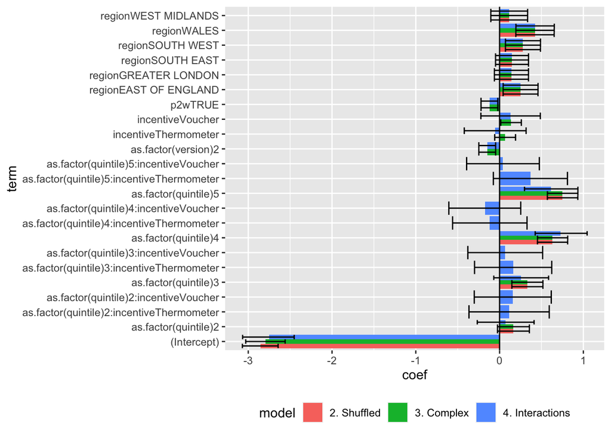

Comparing consent models

```r
plotDT <- rbind(shuffledModelDT, complexModelDT, interactionModelDT)
data.table::setnames(plotDT, c("2.5 %","97.5 %"), c("lo", "up")) # for easier ggplotting

p <- ggplot2::ggplot(plotDT, aes(x = coef, y = term , fill = model)) +
  geom_col(position = "dodge") +
  geom_errorbar(aes(xmax = up, xmin = lo),
                position = "dodge") +
  geom_vline(xintercept = 0) +
  theme(legend.position="bottom")
p
```

```r
ggplot2::ggsave("compareAllModels.png", plot = p,
                path = here::here("plots"))
```

This is easier to see if we have the model results side by side in a table. Stargazer can do that too… and it saves this table for us as well.

```r
stargazer::stargazer(mShuffled, mComplex, mInteraction,
                     type = "html",
                     title="Shuffled Model", digits=3,
                     out=here::here("outputTables","allModels.txt"))
```

**Shuffled Model**

|  | *Dependent variable:* |  |  |
| --- | --- | --- | --- |
|  | consent |  |  |
|  | (1) | (2) | (3) |
| as.factor(quintile)2 | 0.164* | 0.164* | 0.070 |
|  | (0.097) | (0.097) | (0.173) |
| as.factor(quintile)3 | 0.330*** | 0.331*** | 0.254 |
|  | (0.094) | (0.095) | (0.167) |
| as.factor(quintile)4 | 0.630*** | 0.631*** | 0.729*** |
|  | (0.092) | (0.092) | (0.158) |
| as.factor(quintile)5 | 0.750*** | 0.751*** | 0.611*** |
|  | (0.093) | (0.093) | (0.162) |
| incentiveThermometer |  | 0.066 | -0.052 |
|  |  | (0.063) | (0.188) |
| incentiveVoucher |  | 0.137** | 0.130 |
|  |  | (0.063) | (0.181) |
| p2w |  | -0.121** | -0.122** |
|  |  | (0.051) | (0.051) |
| as.factor(version)2 |  | -0.147*** | -0.147*** |
|  |  | (0.051) | (0.051) |
| regionEAST OF ENGLAND | 0.249** | 0.249** | 0.249** |
|  | (0.106) | (0.106) | (0.106) |
| regionGREATER LONDON | 0.140 | 0.140 | 0.140 |
|  | (0.104) | (0.104) | (0.104) |
| regionSOUTH EAST | 0.146 | 0.146 | 0.146 |
|  | (0.100) | (0.100) | (0.100) |
| regionSOUTH WEST | 0.278*** | 0.278*** | 0.278*** |
|  | (0.106) | (0.107) | (0.107) |
| regionWALES | 0.422*** | 0.423*** | 0.424*** |
|  | (0.117) | (0.117) | (0.117) |
| regionWEST MIDLANDS | 0.114 | 0.114 | 0.114 |
|  | (0.112) | (0.112) | (0.112) |
| as.factor(quintile)2:incentiveThermometer |  |  | 0.113 |
|  |  |  | (0.244) |
| as.factor(quintile)3:incentiveThermometer |  |  | 0.161 |
|  |  |  | (0.235) |
| as.factor(quintile)4:incentiveThermometer |  |  | -0.117 |
|  |  |  | (0.226) |
| as.factor(quintile)5:incentiveThermometer |  |  | 0.367 |
|  |  |  | (0.225) |
| as.factor(quintile)2:incentiveVoucher |  |  | 0.157 |
|  |  |  | (0.234) |
| as.factor(quintile)3:incentiveVoucher |  |  | 0.068 |
|  |  |  | (0.228) |
| as.factor(quintile)4:incentiveVoucher |  |  | -0.176 |
|  |  |  | (0.219) |
| as.factor(quintile)5:incentiveVoucher |  |  | 0.041 |
|  |  |  | (0.221) |
| Constant | -2.853*** | -2.792*** | -2.752*** |
|  | (0.109) | (0.120) | (0.157) |
| Observations | 18,000 | 18,000 | 18,000 |
| Log Likelihood | -5,586.562 | -5,577.179 | -5,571.720 |
| Akaike Inf. Crit. | 11,195.120 | 11,184.360 | 11,189.440 |
| *Note:* | p<0.1; p<0.05; p<0.01 |  |  |

Next we test if the model with all the co-variates (but not the interactions) is an improvement using `anova` with the Chisq test method (as our models are logistic):

```r
anova(mShuffled, mComplex, test = "Chisq")
```

|  | Resid. Df | Resid. Dev | Df | Deviance | Pr(>Chi) |
| --- | --- | --- | --- | --- | --- |
| 1 | 17989 | 11173.12 | NA | NA | NA |
| 2 | 17985 | 11154.36 | 4 | 18.76535 | 0.0008739061 |

Looks like it does.

Finally we can test if the model with all the co-variates and the interactions is an improvement on the no-interactions using `anova` with the Chisq test method (as our models are logistic):

```r
anova(mComplex, mInteraction, test = "Chisq")
```

|  | Resid. Df | Resid. Dev | Df | Deviance | Pr(>Chi) |
| --- | --- | --- | --- | --- | --- |
| 1 | 17985 | 11154.36 | NA | NA | NA |
| 2 | 17977 | 11143.44 | 8 | 10.91926 | 0.2063163 |

Nope - and that is what we would suspect given the lack of statistically significant interaction effects.